# Untitled

## 개요

- 데이터 시각화 교과서의 내용 중 그래프를 윈도우 환경에서 `재구현` 해본다.

## 패키지 설치

- 패키지를 설치해본다.
- 패키지는 크게 2가지로 구성되어 있다.
  - 저자가 관리하는 수동 패키지
  - R cran 에서 제공하는 패키지를 설치한다.
- 아래 주석 처리된 패키지는 없다면 별도로 설치해야 하며, 새로운 버전으로 설치가 필요한 경우, 설치한다.

```r
# install.packages("devtools")

# devtools::install_github("wilkelab/cowplot")
library(cowplot)

# install.packages("colorspace")
library(colorspace)

# devtools::install_github("clauswilke/colorblindr")
library(colorblindr)

# devtools::install_github("clauswilke/dviz.supp")
library(dviz.supp)
```

- R에서 제공하는 패키지를 설치해본다.

```r
library(lubridate) # 날짜 관련 패키지
library(forcats)   # 시계열 관련 패키지
library(tidyr)     # 데이터 핸들링 패키지
library(ggrepel)   # 시각화 관련 패키지
library(dviz.supp) # 저자의 개인 Repo 패키지: 교재 있는 데이터 활용 및 그래프를 구현하려면 필수적으로 설치 되어야 함.
library(kableExtra) # 데이터 출력 Table을 HTML로 변환하기 위한 패키지
```

## 데이터 구성

- 교재 내 데이터 역시 모두 저자의 개인 `Repo`에서 관리되고 있다.
  - 참조: https://github.com/clauswilke/dviz.supp
- 즉, `dviz.supp` 라이브러리가 불러오지 않으면 데이터를 쓸수 없다는 뜻이다.

```r
set.seed(3878)

US_census %>% filter(state == "Texas") %>%
  select(name, pop2010) %>%
  extract(name, "county", regex = "(.+) County") %>%
  mutate(popratio = pop2010/median(pop2010)) %>%
  arrange(desc(popratio)) %>%
  mutate(index = 1:n(),
         label = ifelse(index <= 3 | index > n()-3 | runif(n()) < .04, county, ""),
         label_large = ifelse(index <= 6, county, "")) -> tx_counties

kable(tx_counties) %>%
  kable_styling(bootstrap_options = c("striped", "hover")) %>%
  scroll_box(width = "500px", height = "200px")
```

| county | pop2010 | popratio | index | label | label_large |
| --- | --- | --- | --- | --- | --- |
| Harris | 4092459 | 222.6461564 | 1 | Harris | Harris |
| Dallas | 2368139 | 128.8362439 | 2 | Dallas | Dallas |
| Tarrant | 1809034 | 98.4186932 | 3 | Tarrant | Tarrant |
| Bexar | 1714773 | 93.2905174 | 4 |  | Bexar |
| Travis | 1024266 | 55.7241717 | 5 |  | Travis |
| El Paso | 800647 | 43.5584027 | 6 |  | El Paso |
| Collin | 782341 | 42.5624830 | 7 |  |  |
| Hidalgo | 774769 | 42.1505359 | 8 |  |  |
| Denton | 662614 | 36.0488548 | 9 |  |  |
| Fort Bend | 585375 | 31.8467439 | 10 |  |  |
| Montgomery | 455746 | 24.7944073 | 11 |  |  |
| Williamson | 422679 | 22.9954301 | 12 |  |  |
| Cameron | 406220 | 22.0999946 | 13 |  |  |
| Nueces | 340223 | 18.5094935 | 14 |  |  |
| Brazoria | 313166 | 17.0374844 | 15 |  |  |
| Bell | 310235 | 16.8780262 | 16 |  |  |
| Galveston | 291309 | 15.8483760 | 17 | Galveston |  |
| Lubbock | 278831 | 15.1695229 | 18 | Lubbock |  |
| Jefferson | 252273 | 13.7246613 | 19 |  |  |
| Webb | 250304 | 13.6175399 | 20 |  |  |
| McLennan | 234906 | 12.7798270 | 21 |  |  |
| Smith | 209714 | 11.4092813 | 22 |  |  |
| Brazos | 194851 | 10.6006746 | 23 |  |  |
| Hays | 157107 | 8.5472499 | 24 |  |  |
| Johnson | 150934 | 8.2114140 | 25 |  |  |
| Ellis | 149610 | 8.1393831 | 26 |  |  |
| Ector | 137130 | 7.4604211 | 27 |  |  |
| Midland | 136872 | 7.4463849 | 28 |  |  |
| Guadalupe | 131533 | 7.1559219 | 29 |  |  |
| Taylor | 131506 | 7.1544530 | 30 |  |  |

[output cut: 224 more lines]

- 코드가 실행이 안되면, 그것은 `library(dviz.supp)`가 제대로 설치가 안된 것이기 때문에 다시 확인하도록 한다.

```r
income_by_age %>% filter(race %in% c("white", "asian", "black", "hispanic")) %>%
   mutate(race = fct_relevel(race, c("asian", "white", "hispanic", "black")),
          race = fct_recode(race, Asian = "asian", Hispanic = "hispanic"),
          age = fct_recode(age, "≥ 75" = "> 74")) -> income_df

kable(income_df) %>%
  kable_styling(bootstrap_options = c("striped", "hover")) %>%
  scroll_box(width = "500px", height = "200px")
```

| age | year | median_income | race |
| --- | --- | --- | --- |
| 15 to 24 | 2016 | 44588 | white |
| 25 to 34 | 2016 | 65389 | white |
| 35 to 44 | 2016 | 78093 | white |
| 45 to 54 | 2016 | 82289 | white |
| 55 to 64 | 2016 | 69387 | white |
| 65 to 74 | 2016 | 52219 | white |
| ≥ 75 | 2016 | 32203 | white |
| 15 to 24 | 2016 | 45809 | Asian |
| 25 to 34 | 2016 | 80098 | Asian |
| 35 to 44 | 2016 | 100443 | Asian |
| 45 to 54 | 2016 | 98925 | Asian |
| 55 to 64 | 2016 | 91193 | Asian |
| 65 to 74 | 2016 | 56646 | Asian |
| ≥ 75 | 2016 | 26487 | Asian |
| 15 to 24 | 2016 | 30267 | black |
| 25 to 34 | 2016 | 39176 | black |
| 35 to 44 | 2016 | 49336 | black |
| 45 to 54 | 2016 | 50103 | black |
| 55 to 64 | 2016 | 40363 | black |
| 65 to 74 | 2016 | 28697 | black |
| ≥ 75 | 2016 | 22302 | black |
| 15 to 24 | 2016 | 45080 | Hispanic |
| 25 to 34 | 2016 | 45876 | Hispanic |
| 35 to 44 | 2016 | 50245 | Hispanic |
| 45 to 54 | 2016 | 58103 | Hispanic |
| 55 to 64 | 2016 | 51996 | Hispanic |
| 65 to 74 | 2016 | 36704 | Hispanic |
| ≥ 75 | 2016 | 23797 | Hispanic |

## 시각화 1단계

- 우선 교과서 내 소스코드는 모두 깃허브에 저장되어 있다.
  - 참조: https://github.com/clauswilke/dataviz/blob/master/visualizing_amounts.Rmd
- 그런데, 소스코드를 그대로 사용할 경우 교재와 같이 정확하게 나오지 않을 가능성이 크다.

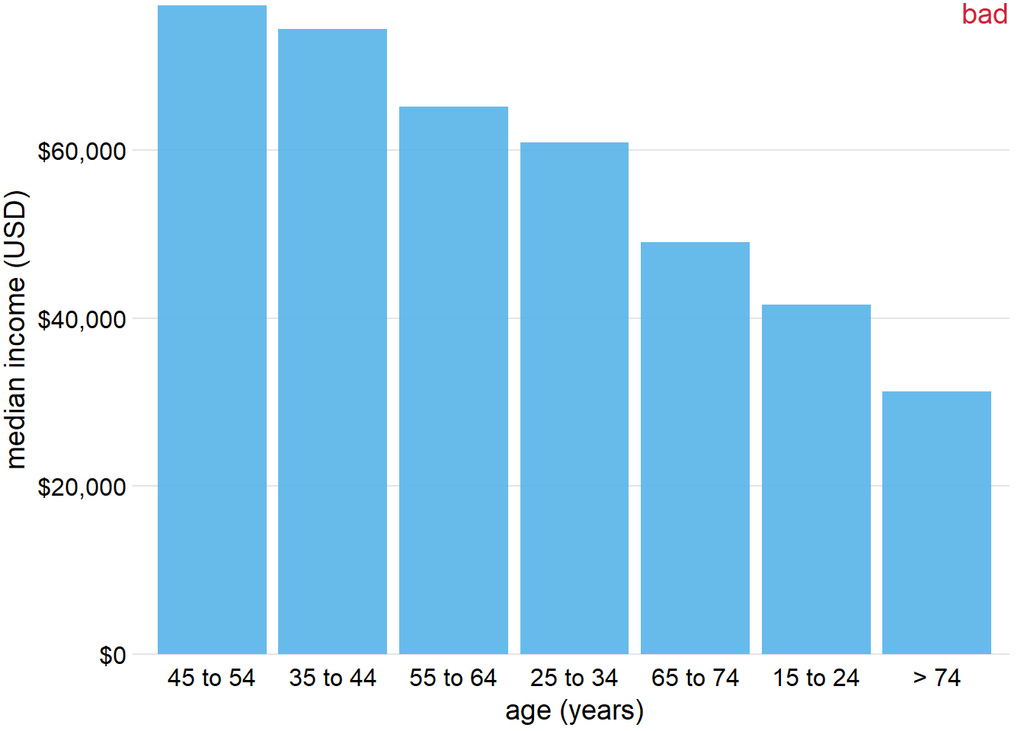

```r
income_by_age %>% filter(race == "all") %>%
  ggplot(aes(x = fct_reorder(age, desc(median_income)), y = median_income)) +
    geom_col(fill = "#56B4E9", alpha = 0.9) +
    scale_y_continuous(
      expand = c(0, 0),
      name = "median income (USD)",
      breaks = c(0, 20000, 40000, 60000),
      labels = c("$0", "$20,000", "$40,000", "$60,000")
    ) +
    coord_cartesian(clip = "off") +
    xlab("age (years)") +
    theme_dviz_hgrid() +
    theme(
      #axis.ticks.length = grid::unit(0, "pt"),
      axis.ticks.x = element_blank(),
      axis.line = element_blank(),
      plot.margin = margin(3, 7, 3, 1.5)
    ) -> p_income_sorted

stamp_bad(p_income_sorted)
```

- 위 시각화와 교재에 있는 시각화와 조금 다르다.
  - 원서: https://serialmentor.com/dataviz/visualizing-amounts.html

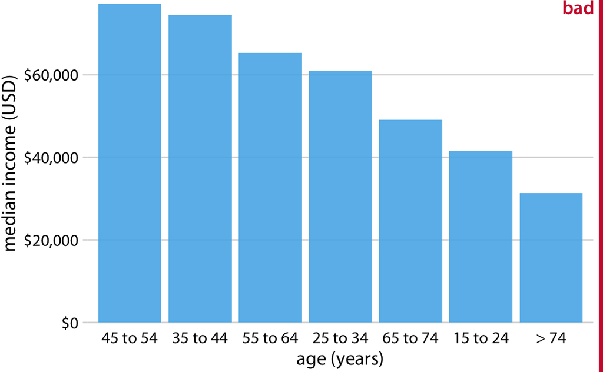

- 그림의 크기는 우선 무시하자.
- 중요한 것은 `bad` 빨간색 라인이 없다는 점이 포인트다.
- 왜 그럴까?
  - `stamp_bad()` 함수가 제대로 기능을 못한 탓이다.
  - 이 함수는 어디에 있을까?
- 마찬가지로 `divz.supp/R` 에서 해당 파일을 찾아야 한다.
  - 참조: https://github.com/clauswilke/dviz.supp/blob/master/R/stamp.R
  - 소스코드는 아래와 같다.

```r
#' Stamp plots with a label, such as good, bad, or ugly.
#'
#' @param p The plot to stamp
#' @param color The color of the stamp
#' @param alpha Transparency level of the stamp
#' @param label The text label used for the stamp
#' @param family Font family
#' @param fontface Font face
#' @param clip Should figure be clipped (default is "on")
#' @examples
#' library(ggplot2)
#'
#' p <- ggplot(iris, aes(x = Sepal.Length, y = Sepal.Width,
#'                       color = factor(Petal.Width))) +
#'   geom_point()
#'
#' stamp_bad(p + guides(color = "none"))
#' stamp_ugly(p)
#' @importFrom cowplot ggdraw draw_text draw_line
#' @export
stamp <- function(p, color, alpha, label, family = dviz_font_family_bold,
                  fontface = "plain", clip = "on")
{
  ggdraw(p, clip = clip) +
    draw_text(paste0(label, "  "), x=1, y=1, vjust=1.1, hjust=1, size=14, angle = 0,
              color=color, alpha=alpha, family = family, fontface = fontface) +
    draw_line(c(1, 1), c(0, 1), size=2.8, color=color, alpha=alpha)
}

#' @rdname stamp
#' @export
stamp_good <- function(p, clip = "on") stamp(p, "olivedrab4", .7, "good", clip = clip)

#' @rdname stamp
#' @export
stamp_phantom <- function(p, clip = "on") stamp(p, "transparent", 0, "", clip = clip)

#' @rdname stamp
#' @export
stamp_bad <- function(p, clip = "on") stamp(p, "#d02138", 1, "bad", clip = clip)
#stamp_bad <- function(p, clip = "on") stamp(p, "#8E202C", 1, "bad", clip = clip)

#' @rdname stamp
#' @export
stamp_wrong <- function(p, clip = "on") stamp(p, "#8E202C", 1, "wrong", clip = clip)

#' @rdname stamp
#' @export
stamp_ugly <- function(p, clip = "on") stamp(p, "#DC9515", 1, "ugly", clip = clip)
```

- 위 함수에 있는 내용을 수정해서 본인에게 맞는 스타일로 재구현해야 한다.
- 이제 시작해보자.

## 시각화 보정

- 이제 `bad`라인을 나타나도록 해보자.
- 일차적으로 시각화를 객체로 담고, 그 이후에 `stamp()` 안에 있는 `ggdraw`를 직접 사용할 것이다.
  - `p_income_sorted` 객체를 직접 사용할 것이다.

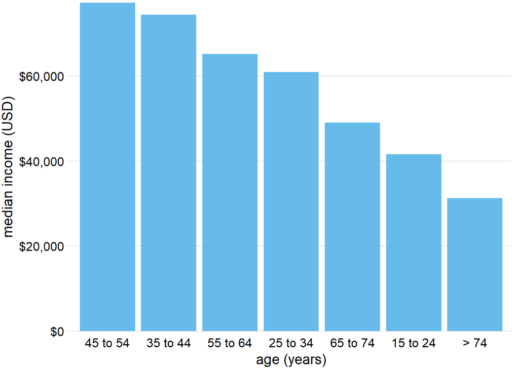

```r
p_income_sorted
```

- 이제 `bad` 선을 구현해보자.

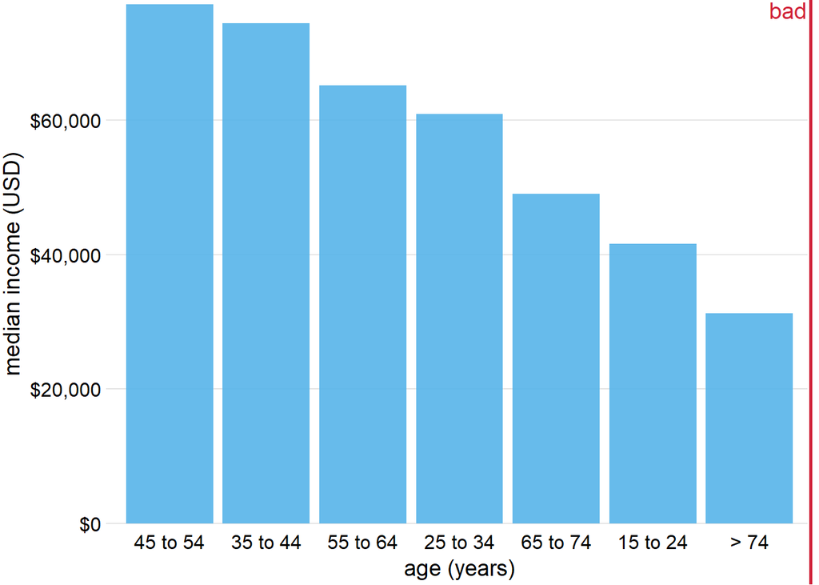

```r
temp_font <- "Times New Roman"

ggdraw(p_income_sorted, clip = "on") +
  draw_text(paste0("bad", "  "), x=1, y=1, vjust=1.1, hjust=1, size=14, angle = 0,
              color="#d02138", alpha=1, family = temp_font, fontface = "plain") +
  draw_line(c(0.99, 0.99), c(0, 1), size=1, color="#d02138", alpha=1)
```

- `draw_line()`은 x와 y 값을 수정하여 라인선을 이동시킬 수 있다. 이 함수 역시, 저자가 개발한 패키지 `cowplot`를 설치하여야 사용할 수 있다는 점을 명심하자.

## 결론

- 가급적 교재를 구입하자.
  - 소스보다 중요한 것은 원리이다!

[figure not shown]

- 저자의 패키지
  - https://github.com/clauswilke/dataviz - RMD 파일을 확인할 수 있다.
  - https://github.com/clauswilke/dviz.supp - RMD내에 있는 별도 R의 소스코드를 확인할 수있다.
  - 그외, https://github.com/wilkelab/cowplot 패키지 역시 설치가 필요하다.
- 다행히, R 4.0.2 버전에서도 정상적으로 구동되는 것을 확인할 수 있다.
- Happy To Code

## 원서 Reference

Wilke, C. (2019). Fundamentals of Data Visualization. Retrieved July 28, 2020, from https://serialmentor.com/dataviz/